# student_performance_lm_ml

Dan Ladd

In this supervised machine learning application, I use a multi-linear regression algorithm to train and validate an academic performance model. The multi-linear regression model allows me to predict a students performance index based on how many hours they have studied, what their previous exam scores were, weather or not they’re involved in extracurricular activities, how much sleep they averaged per night, and how many practice tests they completed.

By exploring feature relationships with the target using statistical methodologies, I determine that linear regression could be a good fit for the objective. All predictor features have a linear relationship with the target feature. Linear regression offers a clear-cut and easily understandable option that requires minimal computational power.

After training and evaluating the model, the results strongly suggest that a linear regression model is a good fit for the problem. The R2 value of 0.99 indicates excellent explanatory power, while the MSE of 4.15 shows that the model predicts values with minimal error. The scatter plot of actual vs. predicted values confirms high accuracy with minimal deviations. Additionally, residual analysis shows a normal distribution centered around 0, with most predictions within an acceptable error range. This evidence, along with the validation set performance, indicates that overfitting is not a concern, and the model is both reliable and good at generalizing to the population.

### Prep work enviorment & import data

```r
library(tidyverse)
library(broom)
library(mlr)
library(mlr3)
library(mlr3learners)
```

```r
# load dataset
student_performance <- read.csv("C:\\Users\\DLadd\\OneDrive - New England College\\Dan\\Data Science\\Portfolio\\data sets\\student_performance.csv")
```

### Review / Preprocess / Wrangle data

```r
# preview features and formats
head(student_performance, 10)
```

```
##    Hours.Studied Previous.Scores Extracurricular.Activities Sleep.Hours
## 1              7              99                        Yes           9
## 2              4              82                         No           4
## 3              8              51                        Yes           7
## 4              5              52                        Yes           5
## 5              7              75                         No           8
## 6              3              78                         No           9
## 7              7              73                        Yes           5
## 8              8              45                        Yes           4
## 9              5              77                         No           8
## 10             4              89                         No           4
##    Sample.Question.Papers.Practiced Performance.Index
## 1                                 1                91
## 2                                 2                65
## 3                                 2                45
## 4                                 2                36
## 5                                 5                66
## 6                                 6                61
## 7                                 6                63
## 8                                 6                42
## 9                                 2                61
## 10                                0                69
```

```r
# Check if there are any decimals present in the Performance.Index variable since it is in double format
any(student_performance$Performance.Index != floor(student_performance$Performance.Index))
```

```
## [1] FALSE
```

```r
# change Performance.Index variable to Integer for consistency
# change Extracurricular.Activities from a character to a factor as required
student_performance <- student_performance %>%
  mutate(Performance.Index = as.integer(Performance.Index)) %>%
  mutate(Extracurricular.Activities = as.factor(Extracurricular.Activities))

str(student_performance)
```

```
## 'data.frame':    10000 obs. of  6 variables:
##  $ Hours.Studied                   : int  7 4 8 5 7 3 7 8 5 4 ...
##  $ Previous.Scores                 : int  99 82 51 52 75 78 73 45 77 89 ...
##  $ Extracurricular.Activities      : Factor w/ 2 levels "No","Yes": 2 1 2 2 1 1 2 2 1 1 ...
##  $ Sleep.Hours                     : int  9 4 7 5 8 9 5 4 8 4 ...
##  $ Sample.Question.Papers.Practiced: int  1 2 2 2 5 6 6 6 2 0 ...
##  $ Performance.Index               : int  91 65 45 36 66 61 63 42 61 69 ...
```

```r
# check to make sure Extracurricular.Activities variable is in-fact binary. R automatically will one-hot encode this feature.
unique(student_performance$Extracurricular.Activities)
```

```
## [1] Yes No
## Levels: No Yes
```

```r
# check for missing data
colSums(is.na(student_performance))
```

```
##                    Hours.Studied                  Previous.Scores
##                                0                                0
##       Extracurricular.Activities                      Sleep.Hours
##                                0                                0
## Sample.Question.Papers.Practiced                Performance.Index
##                                0                                0
```

```r
# reformat data frame into tibble / R best practices
student_performance <- as_tibble(student_performance)

str(student_performance)
```

```
## tibble [10,000 x 6] (S3: tbl_df/tbl/data.frame)
##  $ Hours.Studied                   : int [1:10000] 7 4 8 5 7 3 7 8 5 4 ...
##  $ Previous.Scores                 : int [1:10000] 99 82 51 52 75 78 73 45 77 89 ...
##  $ Extracurricular.Activities      : Factor w/ 2 levels "No","Yes": 2 1 2 2 1 1 2 2 1 1 ...
##  $ Sleep.Hours                     : int [1:10000] 9 4 7 5 8 9 5 4 8 4 ...
##  $ Sample.Question.Papers.Practiced: int [1:10000] 1 2 2 2 5 6 6 6 2 0 ...
##  $ Performance.Index               : int [1:10000] 91 65 45 36 66 61 63 42 61 69 ...
```

### Explore relationships among variables

All predictor features appear to be very statistically significant given p-values of less than 0.05. Extracurricular.Activities and Sample.Question.Papers.Practiced are deceiving at first glance but are actually 0.00 upon close examination.

```r
# Fit a linear model to all data for the purpose of reviewing statistics on predictor variables effect on target variable.

sp_lm <- lm(Performance.Index ~ ., data = student_performance)

sp_lm_stats <- tidy(sp_lm)
print(sp_lm_stats)
```

```
## # A tibble: 6 x 5
##   term                             estimate std.error statistic   p.value
##   <chr>                               <dbl>     <dbl>     <dbl>     <dbl>
## 1 (Intercept)                       -34.1     0.127      -268.  0
## 2 Hours.Studied                       2.85    0.00787     362.  0
## 3 Previous.Scores                     1.02    0.00118     866.  0
## 4 Extracurricular.ActivitiesYes       0.613   0.0408       15.0 1.68e- 50
## 5 Sleep.Hours                         0.481   0.0120       40.0 0
## 6 Sample.Question.Papers.Practiced    0.194   0.00711      27.3 7.46e-158
```

The scatterplots below further indicate linearity among predictor features and the target feature. Positive linear relationships are evidenced by the upward left to right slopes.

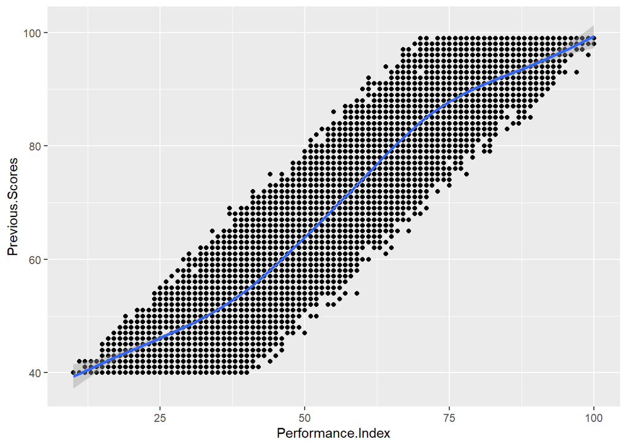

```r
# this scatter plot further supports the appropriateness of applying a linear model to this particular business question.
ggplot(student_performance, mapping = aes(Performance.Index, Previous.Scores))+
  geom_point() +
  geom_smooth()
```

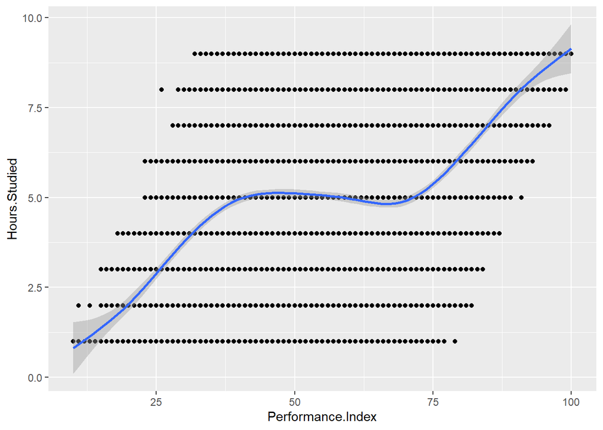

```r
ggplot(student_performance, mapping = aes(Performance.Index, Hours.Studied))+
  geom_point() +
  geom_smooth()
```

### Begin Machine Learning process

Now that I’m convinced a linear model could be a good fit for this problem, I begin the machine learning process.

```r
# set seed to ensure reproducibility in future
set.seed(68)

# partition data into 80% training purposes and 20% validation purposes.
train_index <- sample(row.names(student_performance), 0.80*dim(student_performance)[1])
valid_index <- setdiff(row.names(student_performance), train_index)

train_sp <- student_performance[train_index,]
valid_sp <- student_performance[valid_index,]
```

```r
# create a regression task indicting Performance.Index as the target.
sp_lr_task <- TaskRegr$new(id = "sp_task_id", student_performance, target = "Performance.Index")
```

```r
# create a learner specifying linear regression
sp_lr_learner <- makeLearner("regr.lm", predict.type = "response")
```

```r
# train the model on the training partition
sp_lm <- lm(Performance.Index ~ ., data = train_sp)
```

## Review Predictive Performance of Model

### Basic Accuracy Test

```r
# use predict function to make predictions on the validation data set
sp_lm_predictions <- predict(sp_lm, newdata = valid_sp)

# compare first three predictions vs actual performance
head(sp_lm_predictions, 3)
```

```
##        1        2        3
## 65.56720 72.68182 81.75433
```

```r
head(valid_sp$Performance.Index, 3)
```

```
## [1] 68 71 83
```

### Quantify Model Performance

```r
# Review R-squared
## actual values from validation data
actual_perf <- valid_sp$Performance.Index

## residual sum of squares
ris_sum_squ <- sum((actual_perf - sp_lm_predictions)^2)

## total sum of squares
total_sum_squ <- sum((actual_perf - mean(actual_perf))^2)

r_squ <- 1 - (ris_sum_squ / total_sum_squ)

r_squ
```

```
## [1] 0.9886652
```

```r
# Review Mean Squared Error
mse <- mean((valid_sp$Performance.Index - sp_lm_predictions)^2)

mse
```

```
## [1] 4.151211
```

### Visualize Model Perfromance

By plotting actual vs predicted values, I can see that that the model has minimal scatter. Points fall close to the center line helping to confirm that the model is accurate and the error margins are minimal. The scatter plot also helps show that over fitting is not apparent.

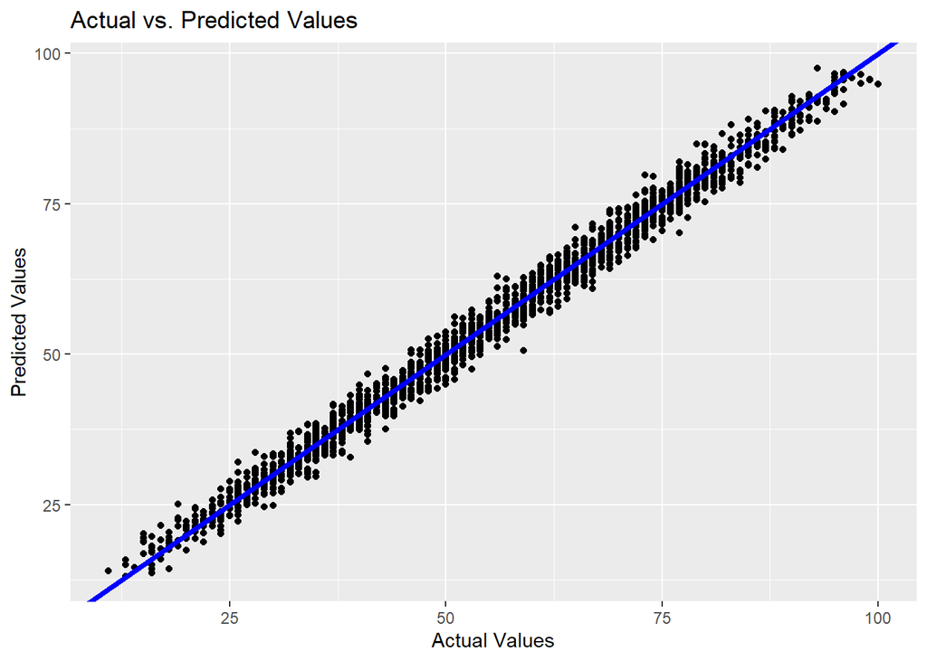

```r
## create a visual of the differences
results <- data.frame(valid_sp$Performance.Index, sp_lm_predictions)

# Scatter plot of actual vs. predicted values
ggplot(results, mapping = aes(x = actual_perf, y = sp_lm_predictions)) +
  geom_point() +
  geom_abline(intercept = 0, slope = 1, color = "blue", size = 1.5) +
  labs(title = "Actual vs. Predicted Values", x = "Actual Values", y = "Predicted Values")
```

### Check Residuals

Visualizing the distribution of the residuals also helps to show that the model is producing accurate predictions that are within an acceptable error range. The normal distribution of residuals shows that the overwhelming majority of predictions are within 2.5 of the actual. Additionally, only a few predictions were off by more than 5 in either direction.

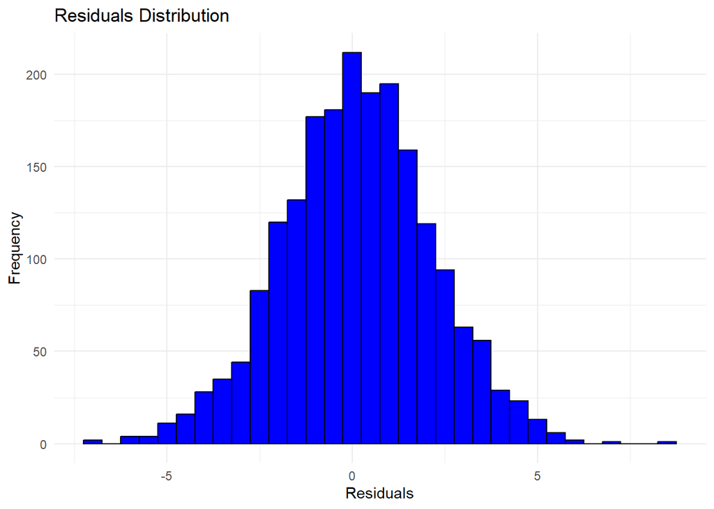

```r
residuals <- valid_sp$Performance.Index - sp_lm_predictions

# Residual plot
ggplot(data.frame(Residuals = residuals), aes(x = Residuals)) +
  geom_histogram(binwidth = 0.5, fill = "blue", color = "black") +
  labs(title = "Residuals Distribution", x = "Residuals", y = "Frequency") +
  theme_minimal()
```